# CGNNPackage

Nole Lin

March 19, 2018

## Explaining the Causal Discovery Toolbox Package

The CDT Package offers an implementation of a Causal Generative Neural Network that can be used to infer causality between various variables. This is a basic rundown of what the package entails.

### Overall Process of Generating DAG

Ultimately, we want to turn observational data into a directed acyclic graph.

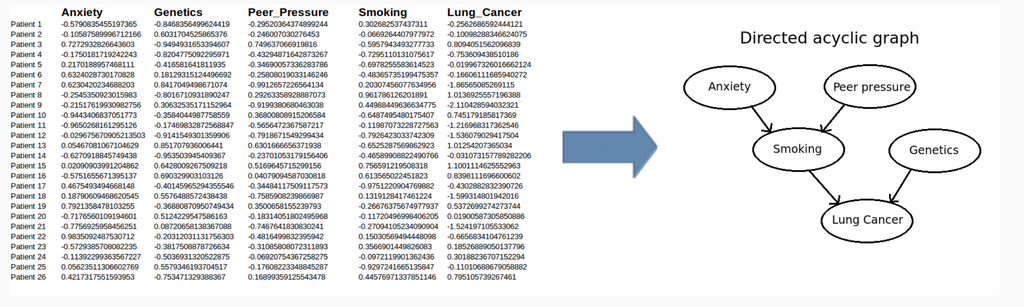

[image link](http://s.interpretable.ml/nips_interpretable_ml_2017_spotlight_talks.pdf)

Using the CDT, we will follow these steps to achieve that:

1. Use a Generative Neural Network to find causality (direction) between pairs of variables using the pairwise approach
2. Use a Causal Generative Neural Network to improve on the DAG given by the GNN using the hill-climbing algorithm

### Pairwise Approach

The pairwise approach involves generating pairs of the variables (V1, V2) and determining the direction of causality between the pairs (V1 -> V2, or V2 -> V1). To do this, we train a neural network with V1 as the input and V2 as the output. Then we compare its performance with V2 as the input and V1 as the output. The loss function we are minimizing for both of these approaches is the Maximum Mean Discrepancy (MMD), which computes the distance between two samples. The framework that achieves best results determines the direction between V1 and V2.

### Hill-Climbing Algorithm

Taking the DAG derived by the Pairwise Approach, we use the Hill-Climbing Algorithm to optimize the DAG. First, we randomly select an edge and consider the score of the resulting graph if we were to reverse the direction of that edge. The CGNN is retrained and if the new graph obtains a better global score than the former one, we continue iterating on the edges.